# Geo-scripting

07 January, 2019

## Did you know?!

Scripting can be used to process satellite data easily to monitor deforestation globally

- Google Earth Engine for global deforestation monitoring
  - https://earthengine.google.org/#intro

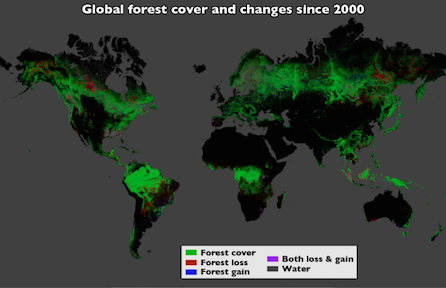

Image Credit: NASA Goddard, based on data from Hansen et al., 2013.

## Why geo-scripting?

[figure not shown]

## Why geo-scripting?

- Reproducible: you keep track of what you have done
- Efficient: you can write a script to do something and repeat your analysis x1000…
- Good for finding errors

Can you think of other advantages?

## Why geo-scripting?

- Enable collaboration
  - a huge social R and Python community

[figure not shown]

## Why geo-scripting?

- Build your own tools and functions (e.g. automated web-processing, etc.)

[figure not shown]

[See Lesson 2 demo's!](https://geoscripting-wur.github.io/Scripting4Geo/#why-scripting)

## Geo-scripting learning objectives

- Read, write, and visualize spatial data using a script
- Find and use functions for geo-data handling
- Know how to find help
  - Write a clear and reproducible script
  - Learn how to help each other
- Apply learned concepts for your own geo-challenge

## The geo-scripting course

Goal:

- Scripting to solve spatial challenges!
- **Learn by doing**
- **Learn how to keep on learning**

A team of `R` & `Python` experts who use geo-scripting languages every day helped to develop this course

## Course concept

Flipped Classroom concept:

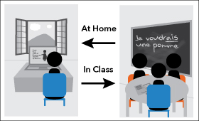

- Experts from companies, research institutes and university will present.

## Team work & helping each other

- Teams of two:
  - select the team (2 persons, e.g. 1st with 2nd year MGI ) and fill in the form (see blackboard)
- Other teams can be selected for the project work

[figure not shown]

## Team work & helping each other

- The Question and Answer forum (see blackboard):
  - Ask at least one good question
  - Answer at least one question
  - *Register with your wur e-mail address today!*

http://www.geo-informatie.nl/courses/grs33806/question2answer/

## Team work & helping each other

**Slack** https://wur-grs.slack.com/messages/geoscripting2019

## Scoring

- All exercises - 30%
- Questions & Answers forum - 10%
- Project - 60%

Details: https://goo.gl/3szHDt Course Guide (google docs)

## Individual assessment

- Question and answer forum
- DataCamp website: challenges
  - Free access to all courses for 6 months
- Script reviewing can be done on an individual basis

## Learning outcomes of today:

- Refreshing and assessing R scripting skills to see if you can continue with the course
- Able to write a function
- Know how to visualize a spatial map in R

*Socrative Quiz at the end of this presentation!*

## What is a scripting language?

- A scripting language can interpret and automate the execution of tasks, instead of clicking!!!
- A scripting language is the glue, between different commands, functions, and objectives without the need to compile it for each OS (e.g. windows)
- This is different from like C/C++/Fortran
  - these are languages that need to be compiled first.

## Compiling

Passing the source code through a compiler, which translates the `high-level language` instructions into an `exe`.

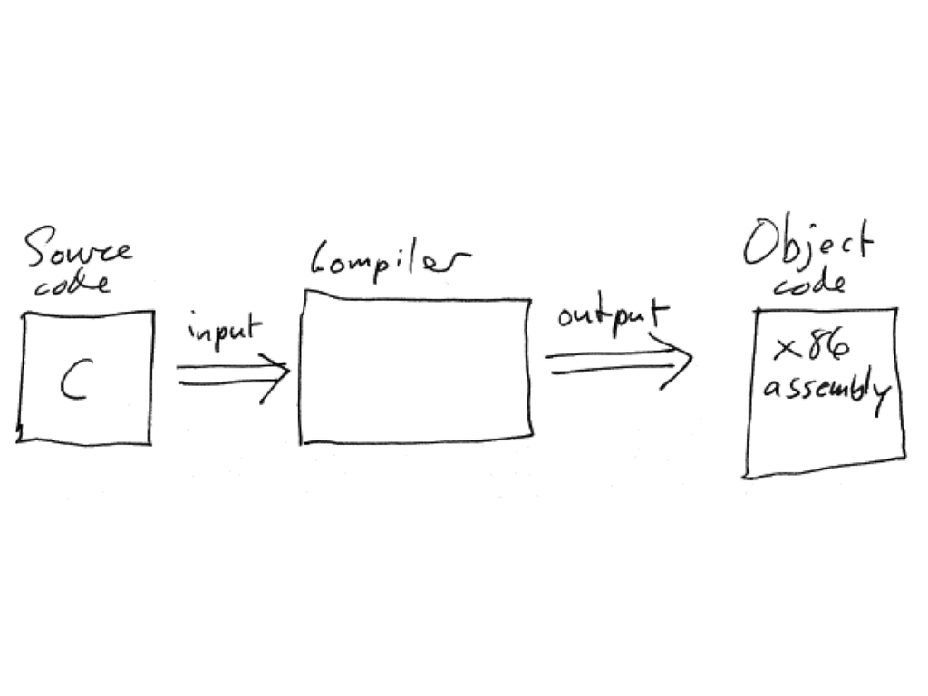

## The main scripting languages for GIS and Remote sensing currently are:

- R
- Python
- GRASS (grass function are included in QGIS)
- JavaScript for geoweb scripting
- Matlab
- IDL (ENVI)
- …

## Python versus R

- Python is a general purpose programming language
- R is particularly strong in statistical computing and graphics
- Syntactic differences between R and Python can be confusing
- There are many R and Python packages for spatial analyses

[figure not shown]

## R packages

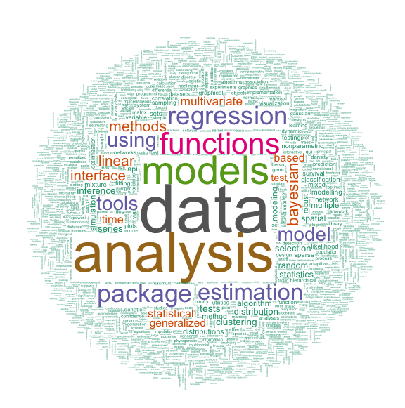

## Many programs have support for

Python & R e.g.:

- QGIS
- GRASS
- PostGIS

## Challenge

Login to socrative: http://www.socrative.com

Room: GEOSCRIPTING

Quiz: Geo-scripting intro

## Time for R action!

- What is a "reproducible script"?

## Reproducibility

[figure not shown]

## Rubric

[Rubric](https://docs.google.com/document/d/1wdqcrqh4Bt-tNwhEFRa4esq7ozwo36tfOjGmbBTK5B4/edit?usp=sharing)

## Tomorrow morning

- Provide feedback
- Lesson 2
  - an overview of what is possible with scripting
  - no need to understand the code: lesson 2 is a demonstration lesson!

[See Lesson 2 demo's!](https://geoscripting-wur.github.io/Scripting4Geo/#why-scripting)